# Rank-Size Patterns in Political Data

The same curve, six times — and how much you leave out before it becomes a law

Democracy’s Data

Last updated September 13, 2026 at 10:53a EDT

American political data is full of quantities where a few things hold nearly all of it. A few candidates raise almost all the money, a few counties hold much of the population, a few surnames cover much of the country. People who work with numbers like these say the same sentence about all of them: *it’s a power law*, meaning that size falls off with rank in a fixed proportion, so that going ten times further down the list always divides the size by the same amount. Is that true, and what does the regularity explain?

The question is worth your time because these are the numbers a news story averages. “The average candidate raised two million dollars” is correct arithmetic and describes almost nobody. Whether such a quantity has a typical value at all decides whether that summary means anything.

## The test

Six quantities are put side by side here, from six places in this book that have nothing to do with each other. How many Americans share a surname. How many people live in a county. How much a candidate raised, how much a committee spent independently, how much outside money went to one candidate, and how many people opened a Wikipedia article on one day. 168,595 values in all.

The six are combined on a key made here rather than one the files carry. Each file is sorted from largest to smallest, every row is given its position in that list, and the six lists are stacked on two columns, `series` and `rank`. Join Keys and Crosswalks states the rule this section keeps returning to, and explains the crosswalk, a table that translates one set of identifiers into another. A number built from two sources inherits the assumptions of both, and the join adds one more about how they line up. Here that extra assumption is that rank 100 in a list of surnames is a comparable position to rank 100 in a list of campaign accounts.

## The data

Every row of `ranks.csv` is one thing and its position in a sorted list.

| Series | Rank | Value | What it is |
| --- | --- | --- | --- |
| Surnames | 1 | 2,369,644 | SMITH |
| Surnames | 10 | 1,039,848 | MARTINEZ |
| Counties | 1 | 10,014,009 | Los Angeles, California |
| Counties | 10 | 2,418,185 | Riverside, California |

| Column | What it holds | Measurement |
| --- | --- | --- |
| series | which of the six quantities this row belongs to | categorical |
| rank | position in that quantity’s sorted list; 1 is the largest | count |
| value | the quantity itself — people, dollars or views | continuous |
| who | the surname, county, candidate, committee or article-day it belongs to | identifier |

Four decisions were taken before any curve was drawn.

**One series had to be rebuilt.** English Wikipedia’s article on JD Vance sat under a different title until July 2024, and the pageview record reports traffic by title. Asked for today’s title, it returned only the readers who arrived through the leftover redirect, so a sitting senator appeared to have a handful of readers a day. Those days sat at the bottom of the smallest series here, and the media-attention chapter now sums every title the article has held.

That correction is the general hazard. **A long tail is where measurement error goes to hide.** A value a thousand times too small is obvious at the top of a ranking and invisible at the bottom, where everything is small anyway.

**The drawing is thinned and the arithmetic is not.** On a logarithmic axis, ranks 100,000 and 100,001 land on the same pixel. The first fifty ranks are kept whole and the rest sampled at even logarithmic intervals: 1,276 drawn points. Every number below comes from all 168,595 values.

Three tables carry the summaries. `summary.csv` holds one row per series, with `n`, `median`, `mean`, `mean_over_median`, `above_mean_pct`, `top1_share` and `gini`. `fits.csv` holds a line fitted at forty-four cut-offs, with `frac`, `k`, `slope` and `r2`, the R² statistic, which is the share of the points’ scatter the line accounts for, 1 being a perfect fit. `zipf.csv` sets each series’ `observed` value beside `zipf`, the prediction, and their `ratio`.

> **Before you read on, commit to a number.** SMITH is the most common surname in the United States, held by 2,369,644 people. **How many people do you think hold the 100th most common surname?** Write the number down before you scroll.

## What it says about democracy

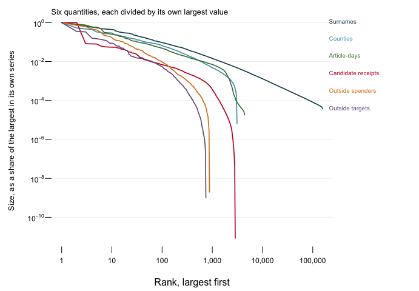

**Figure 1. Six unrelated quantities, each sorted largest to smallest.** Ranking makes six incomparable quantities comparable: each series is divided by its own largest value, so the only thing left to compare is how fast it falls. Both axes are logarithmic. Hover any point to see what it is, and the button redraws the same numbers on ordinary axes.

Try that button. On ordinary axes all six collapse into the same L, a cliff at the left edge then a flat line the rest of the way. That is what a spreadsheet’s default chart gives you when the largest value is millions of times the median. The logarithms are the only reason there is anything to look at, and with them the six run close to parallel over two or three powers of ten in rank.

Read the surname curve off that scale one tick at a time. Rank 1 is SMITH, 2,369,644 people. One tick to the right, since each tick multiplies the rank by ten, is rank 10, MARTINEZ, with 1,039,848 people, 2.3 times fewer. The next tick, rank 100, is LONG with 223,485, 4.7 times fewer than rank 10; the next, rank 1,000, is COMPTON with 34,287, 6.5 times fewer again. The vertical axis is also in ticks of ten, so a straight line would mean the same drop for every step to the right. The drops here grow with each step, and that growing drop is the curve bending downward in Figure 1.

| Series | Rank | What is there | Observed | Zipf predicts | Ratio |
| --- | --- | --- | --- | --- | --- |
| Surnames | 1 | SMITH | 2,369,644 | 2,369,644 | 1.00 |
| Surnames | 10 | MARTINEZ | 1,039,848 | 236,964 | 4.39 |
| Surnames | 100 | LONG | 223,485 | 23,696 | 9.43 |
| Surnames | 1,000 | COMPTON | 34,287 | 2,370 | 14.47 |
| Candidate receipts | 1 | HARRIS, KAMALA | $1,175,189,365 | $1,175,189,365 | 1.00 |
| Candidate receipts | 10 | GALLEGO, RUBEN | $64,657,200 | $117,518,937 | 0.55 |
| Candidate receipts | 100 | RYAN, PATRICK | $8,143,126 | $11,751,894 | 0.69 |
| Candidate receipts | 1,000 | MONROE, KATE M | $424,374 | $1,175,189 | 0.36 |

The oldest version of the claim is the **rank–size rule**, better known as **Zipf’s law** after the linguist George Zipf, who found it in word frequencies and city sizes:[^1] the item at rank *k* is 1/*k* of the item at rank 1, so each step to the right divides the size by exactly ten. So the 100th most common surname should be a hundredth of SMITH. It is not close. LONG is held by 223,485 people, 9.4 times the prediction. Money misses the other way: the 100th best-funded candidate raised $8,143,126, 0.69 of the prediction. Surnames fall away more gently than 1/*k* and money more steeply, so no single number can be *the* exponent for both.

| Series | Things | Median | Mean | Mean over median | Above the mean | Top 1% holds |
| --- | --- | --- | --- | --- | --- | --- |
| Surnames | 156,621 | 264 | 1,677 | 6.3 | 10.6% | 51.1% |
| Counties | 3,100 | 25,774 | 105,050 | 4.1 | 18.4% | 24.1% |
| Article-days | 4,392 | 6,066 | 36,544 | 6.0 | 22.5% | 31.6% |
| Candidate receipts | 2,860 | $95,610 | $2,393,764 | 25.0 | 13.4% | 55.6% |
| Outside spenders | 878 | $225,415 | $4,745,612 | 21.1 | 11.4% | 50.7% |
| Outside targets | 744 | $144,344 | $5,600,333 | 38.8 | 12.8% | 52.2% |

Here is the part that changes how you read a news story. **In every one of these six, the mean describes almost nobody.** The typical candidate in the FEC file raised $95,610; the *average* candidate raised $2,393,764, and only 13.4% are above it. For outside money spent on a candidate the mean is 38.8 times the median, and 95 of 744 clear it. Across all six, the share of things above their own mean runs from 10.6% to 22.5%.

A quantity like this has no typical value in the way height or blood pressure does. “The average committee spent five million dollars” is a statement about HARRIS, KAMALA, divided by 744 and handed to everyone else. The top 1% holds between 24.1% and 55.6% of each total, and the Gini coefficients run 0.760 to 0.923, where 0 means every unit holds the same and 1 that one holds everything.

Now the claim itself. If these are power laws, then size against rank on logarithmic axes is a straight line, and any software will fit one without complaint. The question nobody asks is which part of the data it was fitted to.

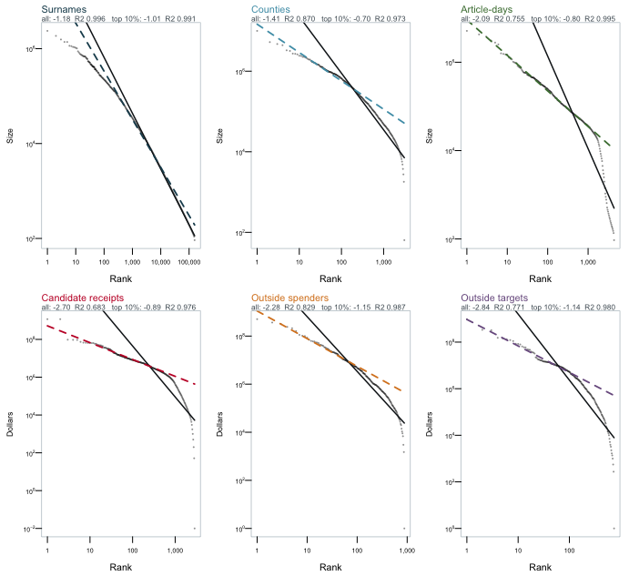

Take candidate receipts. Fitted to the whole file, the line has slope -2.70, meaning the size falls that many powers of ten for each power of ten in rank, and an R² of 0.683, bending away from the data at both ends. Fitted to the top 10%, the same data gives slope -0.89 and R² 0.976. Nothing about the file changed. The 2,574-odd candidates who raised something small were simply left out too.

| Series | Slope, top 10% | R², top 10% | Slope, all of it | R², all of it |
| --- | --- | --- | --- | --- |
| Surnames | -1.01 | 0.991 | -1.18 | 0.996 |
| Counties | -0.70 | 0.973 | -1.41 | 0.870 |
| Article-days | -0.80 | 0.995 | -2.09 | 0.755 |
| Candidate receipts | -0.89 | 0.976 | -2.70 | 0.683 |
| Outside spenders | -1.15 | 0.987 | -2.28 | 0.829 |
| Outside targets | -1.14 | 0.980 | -2.84 | 0.771 |

That pattern holds for all six. Over the full range exactly one is straight: people sharing a surname, R² 0.996. The rest run down to 0.683. Fit only the top decile and **every one is a clean power law**, R² at worst 0.973, all six slopes inside the band from -1.15 to -0.70.

A power law is a claim about the tail, so fitting only the tail is normal. But “only the tail” is a free choice, and the shorter it is the better any falling curve fits a line. **A high R² from a tail-only fit is not evidence of a power law. It is evidence that you chose a short tail.**

Two ordinary mechanisms produce these curves.[^2] A thing that grows by a random *percentage* of its size each period, rather than by a random amount, ends up heavy-tailed and curved over the whole range. Counties grow that way, and so does a surname passed down a family tree. A thing whose chance of getting the next unit is proportional to how much it already has gives a genuine power law instead. Campaign money has an obvious version: donors give to candidates who look viable, and looking viable means having raised money.

A third source of shape is written into the file rather than the world. The FEC has reporting thresholds, the Census suppresses names held by fewer than 100 people, and a county cannot have fewer than zero residents. The bottom of every one of these curves is partly a fact about administration, which is why the slider matters. The fit using the most data is also the one most shaped by filing rules.

## What this brief cannot tell you

**These six lists are not the same kind of object.** Surnames and counties are close to complete enumerations. Candidate receipts and committee spending exist only because a filing rule requires them, so a rule sets their bottom ends; the smallest receipts total is $0.01, filed by PARK, CHARLES. And pageviews count requests to a machine, not readers.

**Concentration is not the same as unfairness, and this brief measures the first.** That 55.6% of a total sits with 1% of the units is a description. Whether it is a problem depends on arguments about representation that no exponent settles, and that the campaign-finance and independent-expenditures chapters take up.

## What you should have learned

- Six political quantities collected for unrelated reasons, 168,595 values in all, fall on nearly the same curve when sorted largest to smallest on logarithmic axes.
- The mean of such a quantity describes almost nobody: only 10.6% to 22.5% of things are above their own series’ average.
- How straight the curve looks depends on how much of it you fit. Over the whole range the six run down to an R² of 0.683; over the top 10% the worst is 0.973.
- A fitted exponent is not a property of the data until you say where you stopped. Campaign receipts give -0.94 on the top 1% and -2.70 on the whole file.
- The bottom of one of these curves is partly a fact about filing rules, which is also where a bad measurement is hardest to see.

## Extensions

Each can be answered by sorting or grouping in a spreadsheet, and none is answered above.

- `summary.csv` carries `mean_over_median` and `above_mean_pct`. Compare the columns across the six rows. What do surnames, counties, money and readers share?
- `fits.csv` fits the same line to different fractions of each series. Sort one series by `frac` and follow `r2`. How much do you discard before it looks like a law?
- `zipf.csv` puts `observed` beside `zipf`, with a `ratio`. Find where the rule breaks for each series, and say whether it breaks at the top or in the tail.
- `summary.csv` reports `top1_share` and `gini`. Which of the six is most concentrated, and could one explanation cover all six?

Two go past the spreadsheet. Add a seventh quantity, such as city populations, and see whether its slope lands inside the band these six occupy. Or refit the receipts series after dropping every candidate below the FEC’s reporting threshold, and decide which slope you would report.

## Sources

**Data**

- U.S. Census Bureau. *Frequently Occurring Surnames from the 2010 Census.* Names held by fewer than 100 people are not published individually. Captured and committed by this book’s surnames chapter. https://www2.census.gov/topics/genealogy/2010surnames/names.zip, described at https://www.census.gov/topics/population/genealogy/data/2010_surnames.html
- U.S. Census Bureau. *2020 Decennial Census*, county population, committed by this book’s mapping chapter. https://www.census.gov/programs-surveys/decennial-census/decade/2020/2020-census-results.html
- Federal Election Commission. *Candidate summary file*, 2023–2024 cycle, and *independent expenditures*, same cycle, committed by this book’s campaign-finance and finance-network chapters. https://www.fec.gov/data/browse-data/?tab=bulk-data
- Wikimedia Foundation. *Pageviews API*, English Wikipedia, daily, 2024, committed by this book’s media-attention chapter. https://wikimedia.org/api/rest_v1/#/Pageviews%20data
- Zipf, George K. (1949). *Human Behavior and the Principle of Least Effort.* Addison-Wesley. The origin of the 1/*k* rule. A scanned copy is at https://archive.org/details/in.ernet.dli.2015.90211
- Clauset, Aaron, Cosma Rohilla Shalizi and M. E. J. Newman (2009). “Power-Law Distributions in Empirical Data.” *SIAM Review* 51(4): 661–703. The test this brief declines to shortcut. Preprint at https://arxiv.org/abs/0706.1062
- Gabaix, Xavier (2016). “Power Laws in Economics: An Introduction.” *Journal of Economic Perspectives* 30(1): 185–206. On the mechanisms above. https://www.aeaweb.org/articles?id=10.1257/jep.30.1.185

**The data itself**

Every figure above is drawn from these tables, which open in a spreadsheet.

`fits.csv`, `ranks.csv`, `summary.csv`, `zipf.csv`

One more file is not data about the subject – it is how this chapter checked its own numbers: `facts.csv`, the individual numbers the text above quotes.

[^1]: George Kingsley Zipf, *Human Behavior and the Principle of Least Effort* (Cambridge, Mass.: Addison-Wesley, 1949), https://archive.org/details/in.ernet.dli.2015.90211.
[^2]: Both are set out for non-specialists in Xavier Gabaix, “Power Laws in Economics: An Introduction,” *Journal of Economic Perspectives* 30, no. 1 (2016): 185–206, https://www.aeaweb.org/articles?id=10.1257/jep.30.1.185.
[^3]: Aaron Clauset, Cosma Rohilla Shalizi and M. E. J. Newman, “Power-Law Distributions in Empirical Data,” *SIAM Review* 51, no. 4 (2009): 661–703, https://arxiv.org/abs/0706.1062.